# Simple Linear Regression

Sick of stats? Get in line!

P. Lombardo

## Loading packages, etc.

```r
library(tidyverse)
library(patchwork)
library(DescTools)
library(broom)
knitr::opts_chunk$set(
  fig.width = 5, fig.height = 4.2, fig.align = 'center'
)

skincancer<-read.csv('data/StateSkinCancer.csv', header = T,
                     stringsAsFactors = T)
cancerlm<-lm(mortality~latitude, data = skincancer)

wine<-read.csv('data/wine.csv', header = T,
               stringsAsFactors = T)

bboom<-read.csv('data/babyboom_nonlin.csv',header = T,
                     stringsAsFactors = T)

# fake "nice" data:
set.seed(15123)
x<-rnorm(100,100,10)
y<-1.4*x - 50 + rnorm(100,0,12)
good_lm_data<-data.frame(x = x, y = y)
```

## Exploring with the `wine` data set

Some research questions:

- Is there an association between `Malic.acid` and `Phenols` when all wine types are considered together? *Specifically,* we believe that as malic acid content increases, phenols will decrease.
- Assuming a relationship exists, treat `Malic.acid` as the response variable. Fit and interpret a regression analysis for this relationship.
- Create visuals!

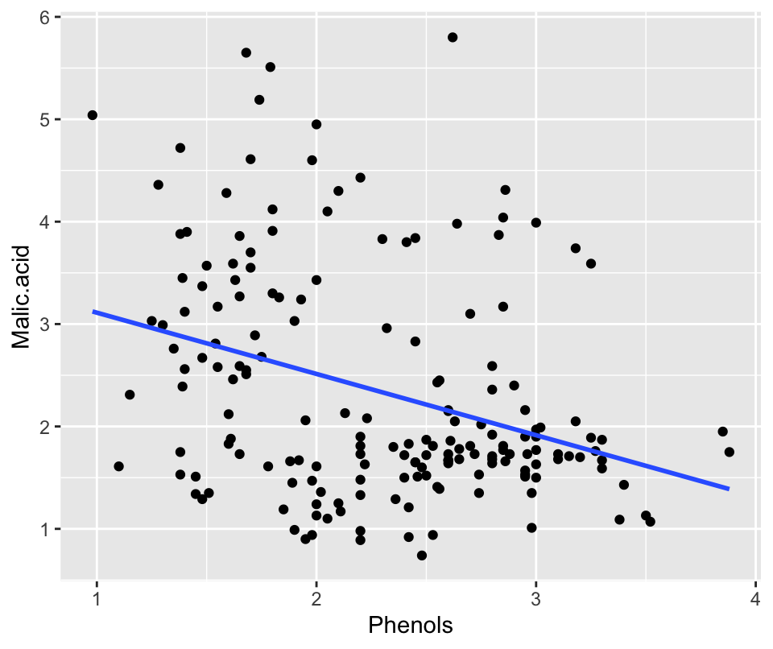

```r
ggplot(data = wine,
       aes(x = Phenols, y = Malic.acid))+
    geom_point()+
    geom_smooth(method = "lm", formula = "y~x", se = F)
```

Summaries:

```r
wine %>%
    summarise(
        corr = cor(Phenols, Malic.acid),
        sampsize = n()
    )
```

| corr | sampsize |
| --- | --- |
| -0.335167 | 178 |

Inference:

1. Typically we do a correlation test first. We believe that the relationship is a negative correlation, so that’s is actually going to be our alternative hypothesis. (We’re setting up the $H_0$ to fail.)

$H_0: \rho \geq 0$

$H_1: \rho < 0$

```r
wine %>%
    with(
        cor.test(Phenols, Malic.acid,
                 alternative = "less")
    ) %>% tidy() %>%
    select(p.value)
```

| p.value |
| --- |
| 2.402123e-06 |

The $P$-value (0.0000024) is less than our significance level (0.05), so we have sufficient evidence to suggest the null hypothesis is wrong. We do have evidence for a negative correlation.

2. If the correlation test is significant, fit and interpret the linear model:

```r
wine.model <- lm(Malic.acid ~ Phenols, data = wine)
# coefficients
wine.model %>%
    tidy() %>% select(term, estimate, p.value)
```

| term | estimate | p.value |
| --- | --- | --- |
| (Intercept) | 3.7094547 | 1.682100e-25 |
| Phenols | -0.5982741 | 4.804246e-06 |

1. Interpretation:
- We can use the line ( avg. malic acid = 3.7 -0.6*phenols) to predict the average malic acid content based on a provided phenols content.
- *Slope interpretation*: If the Phenols amount increases by 1-unit, we would expect on average the malic acid to *decrease* by 0.6 units.
2. Model-fit:

```r
wine.model %>% glance() %>% select(r.squared,sigma)
```

| r.squared | sigma |
| --- | --- |
| 0.1123369 | 1.055515 |

- R-squared: About 11.2% of the variation in malic acid levels can be associated (non-causally) to the linear relationship to phenols.
- Residual Standard Error (RSE): on average, if we use the prediction line to guess a malic acid level, we will be off by about 1.05 units.

The model fit is not the best, based on the small R-squared value. (If I knew more about malic acid content of wines, the RSE might give me more information, but I don’t.)

## Modeling assumptions

The following data, `bboom` looks at birth rates from the years 1940 through about 1995. Let’s visualize this, and overlay a linear regression line:

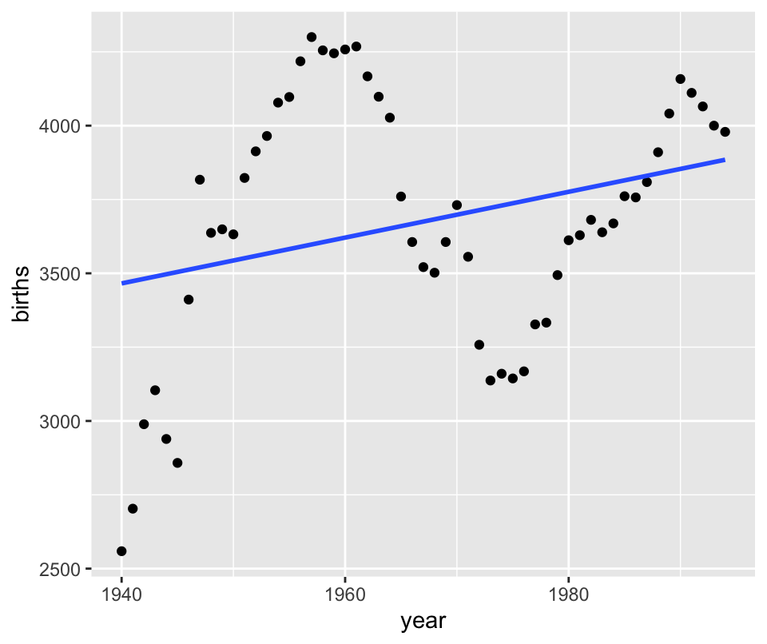

```r
# bboom %>% str()
# place code here
ggplot(data = bboom,
       aes(x = year, y = births))+
    geom_point() +
    geom_smooth(method = "lm", formula = 'y~x', se = F)
```

*What’s the problem with linear regression in this setting?*

If we didn’t visualize first, what would our analysis say?

```r
# place code here
bboom.model <-lm(births~year, data = bboom)
bboom.model %>% tidy() %>%
    select(term, estimate, p.value)
```

| term | estimate | p.value |
| --- | --- | --- |
| (Intercept) | -11577.459596 | 0.1016701 |
| year | 7.754257 | 0.0325990 |

Notice that we get a $P$-value under 0.05 for the slope term, suggesting we have evidence of a linear relationships.

*What’s the point?* You can run a regression analysis without visualizing or checking the modeling assumptions, and you can think you found a linear relationship where it doesn’t exist!

## Linear Regression modeling assumptions:

Checking these assumptions visually.

- Here’s what they look like on a “good” model:

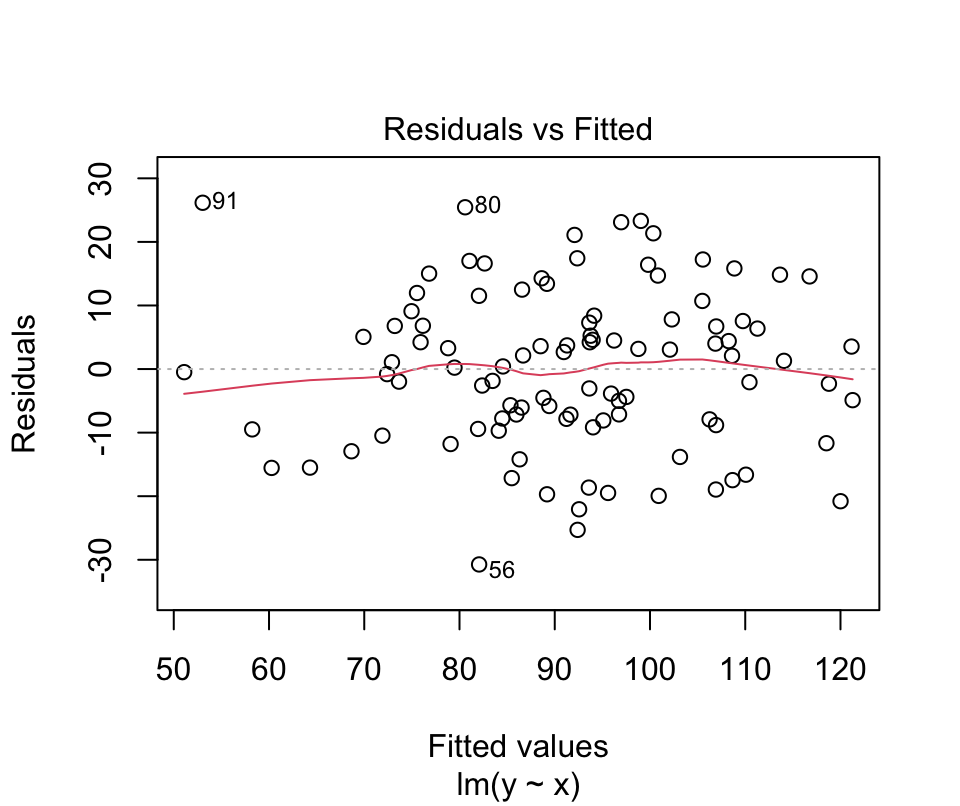

```r
good.model<-lm(y~x, data = good_lm_data)
plot(good.model,which =1)
```

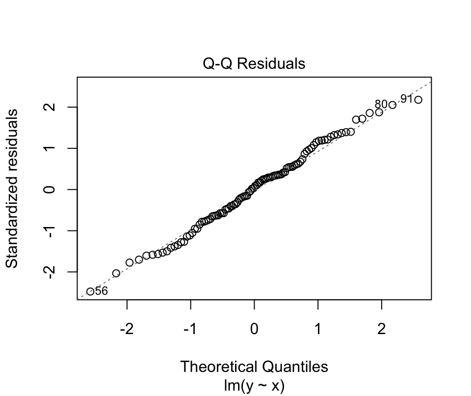

```r
plot(good.model,which =2)
```

- Here’s what they look like on our bad, baby-boomer model:

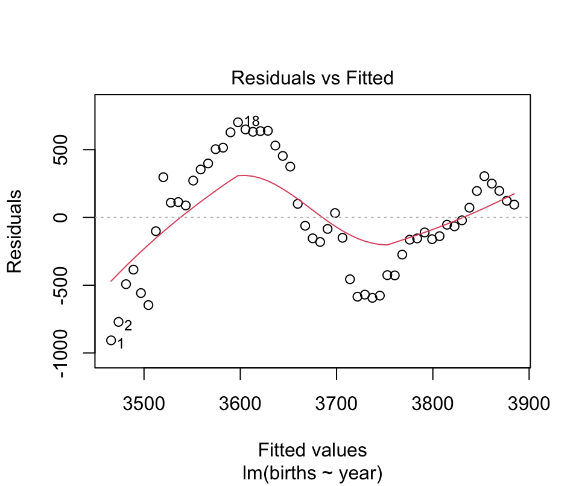

```r
# bad model
plot(bboom.model, which = 1)
```

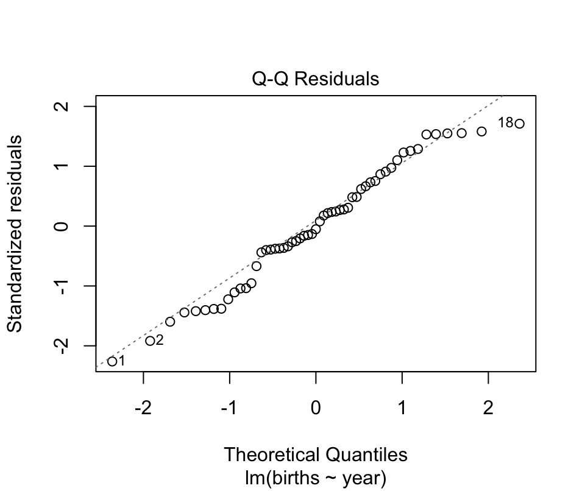

```r
plot(bboom.model, which = 2)
```

*What do we want from these “modeling assumption visuals”?*

1. The Residual versus fitted plot:
- This plot should look like random scatter with no preference above or below zero.
  - Any predictable/noticeable trend in this plot usually indicates a violation of the *linearity* assumption for the response/explanatory relationship (**L**).
- As we move left to right in the plot, the variation in the dots (their spread from the center line of 0) remains about equal. (This shows us our equal variance assumption is satisfied (**E**)).

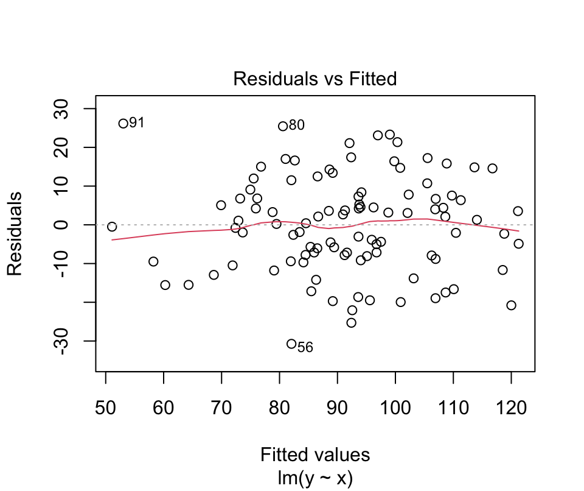

```r
plot(good.model, which = 1)
```

2. QQ-plot checks for normality of the residuals.
- We want the dots to follow the dotted-line in the background, and this gives evidence that our residuals are normally distribution (**N**).

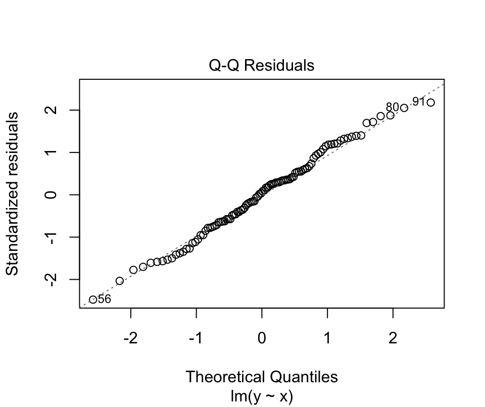

```r
plot(good.model, which = 2)
```

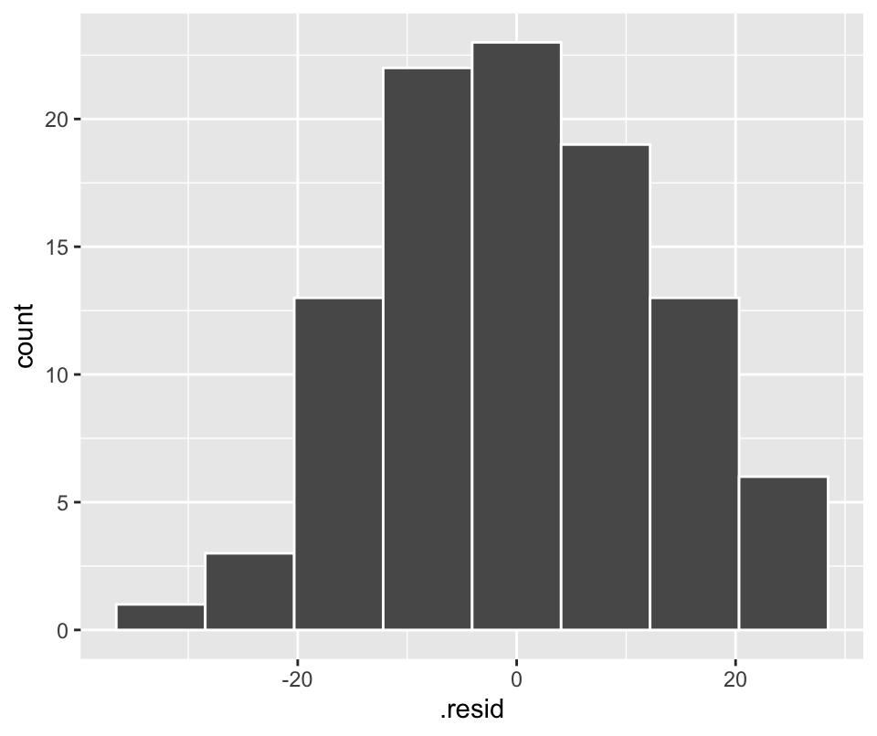

```r
# You can also just plot a histogram of the residuals.
good.model %>% augment() %>%
    ggplot(data = .,
           aes(x = .resid))+
    geom_histogram(bins = 8,color = 'white')
```

> **Main idea:** If your residual vs. fitted plot, or the qq-plot, do not seem to follow what you’re hoping for, this indicates you may be violating an important modeling assumption. Get some extra eyes on the problem and ask an expert or someone with some more training in linear models.

## Exploring the `iris` data frame: Petal.Width ~ Sepal.Width.

Let’s build out this analysis together!

**Work here:**

```r
iris.model<-lm(Petal.Width ~ Sepal.Width, data = iris)
iris.model %>% tidy() %>%
    select(term, estimate, p.value)
```

| term | estimate | p.value |
| --- | --- | --- |
| (Intercept) | 3.1568723 | 2.474053e-12 |
| Sepal.Width | -0.6402766 | 4.073229e-06 |

There appears to be evidence of a linear relationship between Sepal width and petal width. Specifically, as sepal width increases we expect petal width to *decrease* on average.

*But, shouldn’t we check our assumptions and visualize?*

Yes!

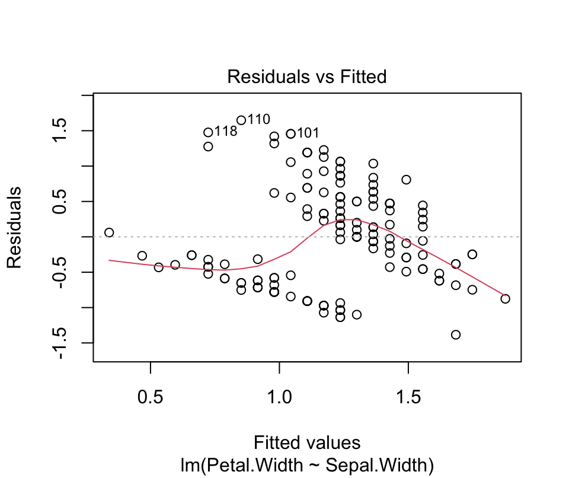

```r
plot(iris.model, which = 1)
```

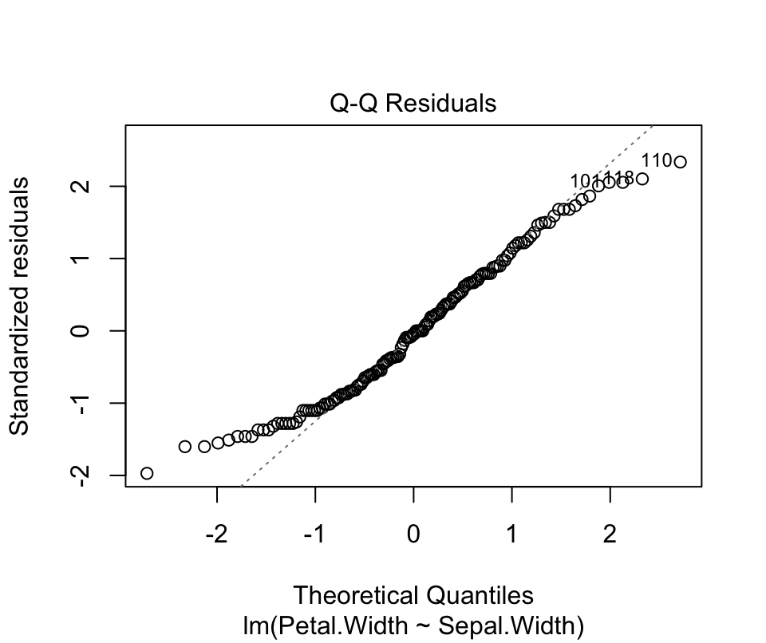

```r
plot(iris.model, which = 2)
```

The residual vs. fitted plot may convince me to visualize the data again.

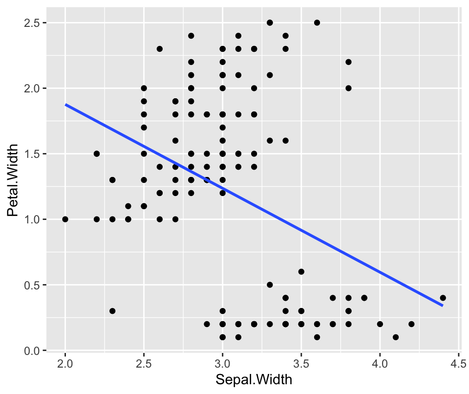

```r
ggplot(data = iris,
       aes(x = Sepal.Width, y = Petal.Width))+
    geom_point()+
    geom_smooth(method = 'lm', formula = 'y~x', se = F)
```

*Hmmmm,* it looks the the data is clumping into two groups. We have the group in the upper left, and a group in the lower right. Within each group, the relationship does not seem negative, in fact it might even look positive.

Oh wait, this data set contains information on three different species of iris! Perhaps the Species has something to do with the bad modeling fit?

Visuals to the rescue!

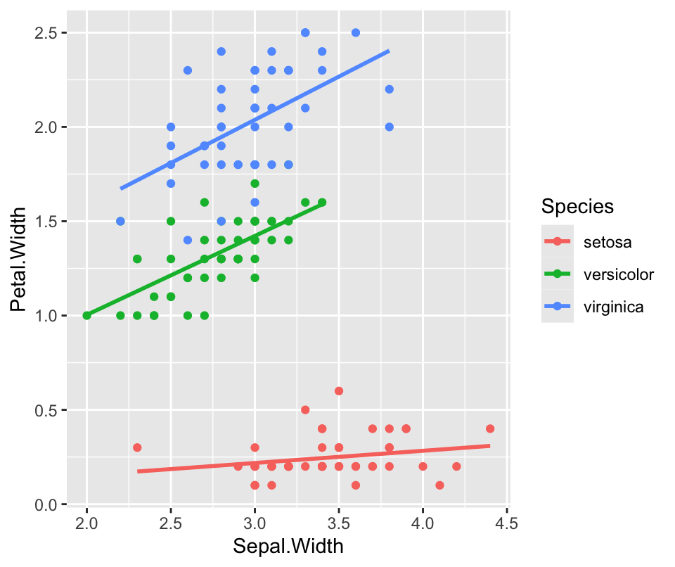

```r
ggplot(data = iris,
       aes(x = Sepal.Width, y = Petal.Width, color = Species))+
    geom_point()+
    geom_smooth(method = 'lm', formula = 'y~x', se = F)
```

If we look at regression lines within each species, the negative trend is reversed! Simpson’s paradox!! ***